# CÁC BƯỚC ĐỂ NHẬN DIỆN KHUÔN MẶT - FACE RECOGNITION

## 1. Phát hiện khuôn mặt trong khung hình bằng thuật toán Haar Cascade

[Tham khảo: Haar Cascades, Explained](https://medium.com/analytics-vidhya/haar-cascades-explained-38210e57970d)

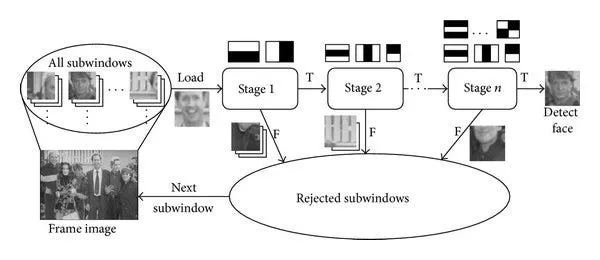

##### Đối với mỗi ảnh đưa vào (input), thuật toán sử dụng kỹ thuật ***Slide Windows***, với nhiều kích thước khác nhau để quét qua toàn bộ ảnh. Trong câu lệnh dưới, tham số `scaleFactor` là chỉ số quyết định kích thước ảnh thay đổi đối với mỗi lần quét.

- Ví dụ `scaleFactor=1.03` -> tăng/giảm 3% kích thước cửa sổ mỗi lần quét.

```python
rects = detector.detectMultiScale(gray, scaleFactor=1.03,
	        minNeighbors=21, minSize=(30, 30),
	        flags=cv2.CASCADE_SCALE_IMAGE)
```

##### Trong mỗi cửa sổ đó, ta dùng đặc trưng Haar để nhận diện khuôn mặt, với 3 tập đặc trưng như sau:

- Đặc trưng cạnh (Edge feature)
- Đặc trưng đường (Line feature)

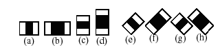

- Đặc trưng quanh tâm (Center-surround feature)

##### Ta tính giá trị của đặc trưng Haar dựa trên sự chênh lệnh giữa tổng pixel của vùng đen và vùng trắng, theo công thức sau:

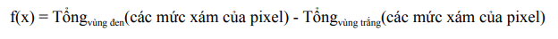

##### Số lượng pixel trong một ảnh rất lớn, nên để tính được giá trị của đặc trưng nhanh hơn, Viola-Joines dùng ***Integral Image*** (Ảnh tích phân - Ảnh chia nhỏ), là một 2D-Array với kích thước bằng với kích thước ảnh gốc. Cách tính minh họa như hình bên dưới:

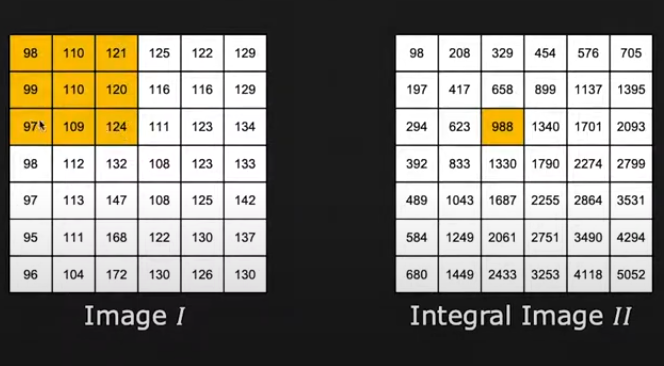

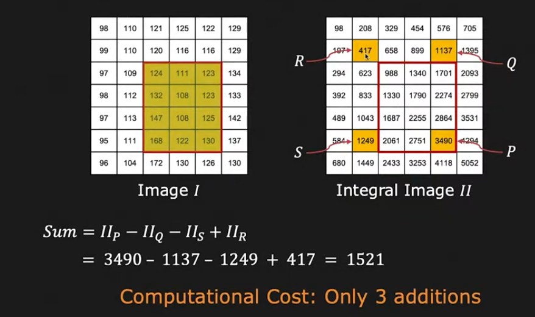

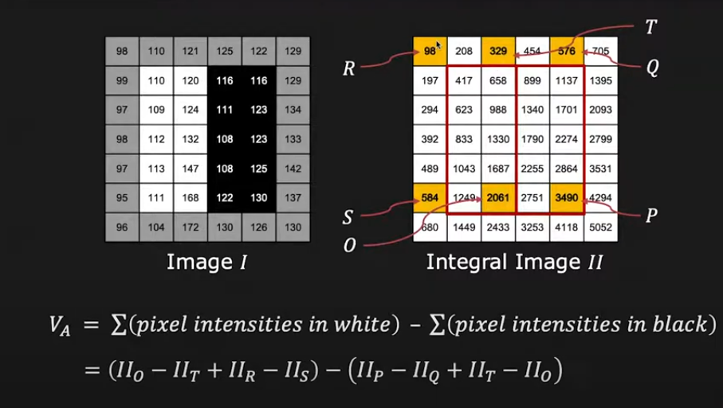

##### Trong một cửa sổ, có rất nhiều những đặc trưng được tính toán và so sánh, nhưng những đặc trưng đó tương đối yếu - "weak classifier", tỉ lệ chính xác thấp trong việc dự đoán có phải khuôn mặt hay không? Do vậy, cần kết hợp các "weak classifier" thành "strong classifier" bằng việc sử dụng kỹ thuật học máy ***AdaBoost (adaptive boosting)***

- Boosting: kết hợp các "weak classifier" tạo thành một "strong classifier":

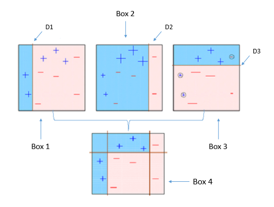

- Adaptive: đặc *trọng số - weight* cho các "weak classifier" tốt hơn, lặp lại liên tục để tạo thành một chuỗi cascade - một "strong classifier" với độ chính xác cao:

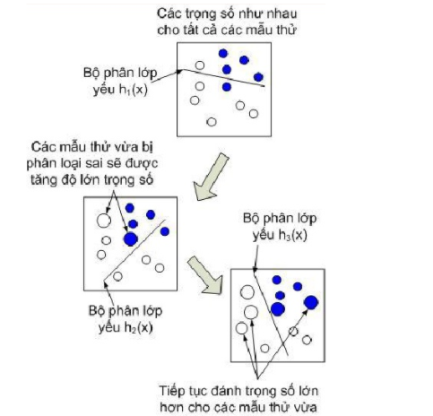

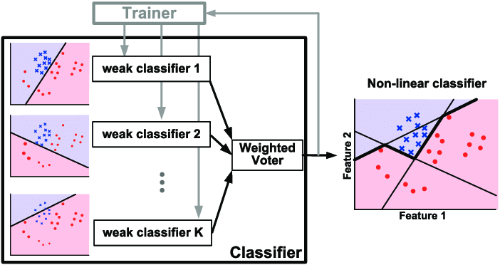

##### Qua AdaBoost, chúng ta đã có những đặc trưng tương đối mạnh. Tuy nhiên, để đưa ra quyết định rằng cửa sổ này là khuôn mặt thì ta cần hàng ngàn (6000+) đặc trưng như thế; vì vậy, ta cần dùng Cascade để phân loại một cách nhanh chóng.

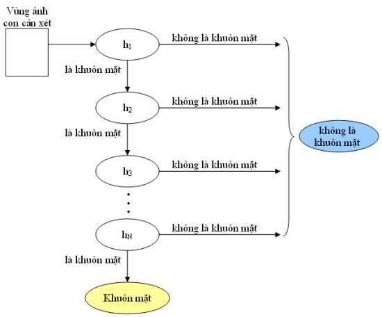

##### Cascade - Phân tầng: mỗi lần trượt cửa sổ, thực hiện thứ tự từng bước: nếu bước 1 quyết định là mặt -> chuyển sang bước 2, rồi đến bước tiếp theo...; nếu không thì bỏ quả và trượt tiếp cửa sổ. Một cửa sổ được quyết định là chứa mặt người thì phải pass qua toàn bộ các tầng này.

[figure not shown]

[figure not shown]

## 3. Nhận diện khuôn mặt dựa trên tập dữ liệu khuôn mặt hiện có